# Blog: Monroe County Climate Data

Viraj Singh

2/20/2017

Data are sampled from a weather station in Monroe County(Everglades),Florida. Analyzed maximum and minimum temperature by month since 1924 to present to account for daily changes in temperature(night vs day).

### Example TMAX data for the month of May

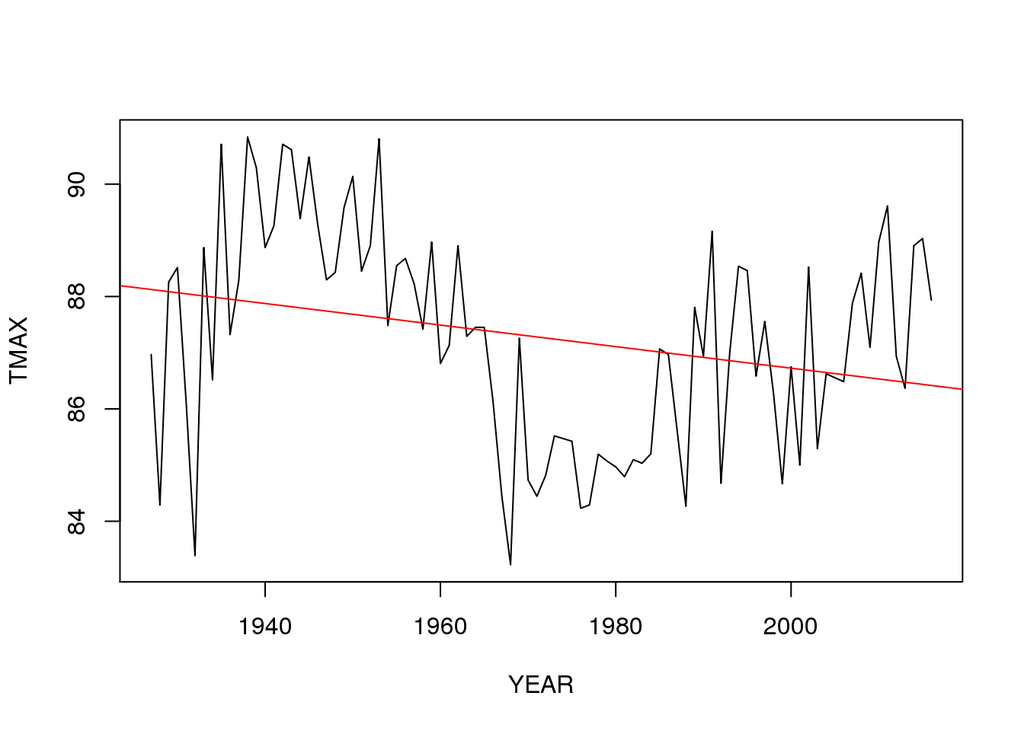

The change or slope is -0.0191845 degress/year or -1.918 degress/100 years with a probability of 0.015. Since the probability is less than .05, we can reject the null hypothesis and there is a trend.

## Table of Slopes(degrees/100 years) and P values for TMAX:

```
##             Slope P-Value
## January   -3.8600  0.0047
## February  -3.6170  0.0149
## March     -2.0200  0.0882
## April     -3.7960  0.0001
## May       -1.9180  0.0150
## June      -1.6970  0.0468
## July      -1.3600  0.0242
## August    -1.9130  0.0070
## September -1.3770  0.0224
## October    0.3090  0.6917
## November  -0.1000  0.9195
## December  -0.2850  0.8258
```

**Analysis of TMAX values:**

January, February, April, May, June, July, August, September(8/12 months) violate the null hypothesis. If the null hypothesis is violated, a negative relationship(as time passes tmax decreases) since 1924 is assumed. While my data in the area shows cooling based on the TMAX values since 1924, saying that this data invalidates claims that net warming on a global level is causing the melting of land ice and thermal exapnsion of the ocean leading to increased sea level would be a hasty generalization. This data is coming from one weather station in the Everglades of Monroe County. Even though max temperatures in the local area are cooling, the global temperature as reported by the IPCC is increasing which contributes to the melting of ice in from large on land icesheets such as that in Greenland.

Now we will examine the minimum monthly temperatures examined across the various months to see if there is a trend. The criteria for noting a trend if the null hypothesis is violated still stands. If the p value is less than .05 the null hypothesis is violated.

## Example TMIN data for the month of May

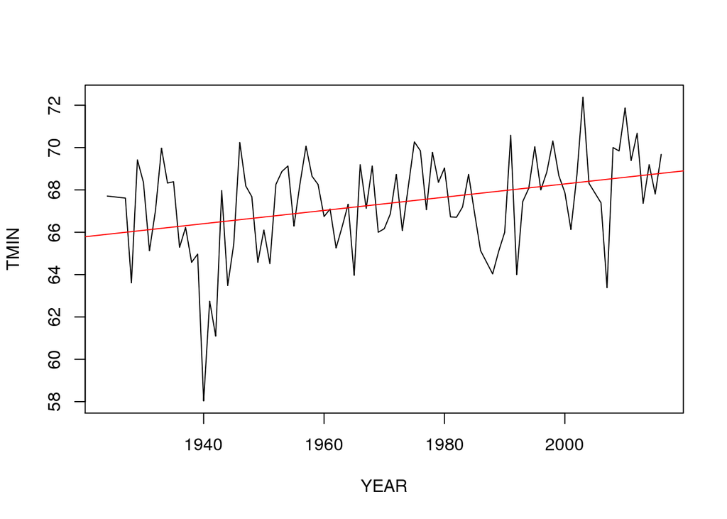

In this case, we get a slope, 0.031287 degress/year and a probability of 8.15610^{-4} and an r-sqaured of 0.123. Since the p value is less than .05, the null hypothesis is violated and there is a trend.

## Table of Slopes(degrees/100 years) and P values for TMIN:

```
##           Slope  P-Value
## January   -1.883 .2564
## February  -.441  .78895
## March     1.338  .3638
## April     .9916  .3760
## May       3.129  .0008
## June      3.1596 2.93e-07
## July      -1.725 .608
## August    2.542  7.41e-06
## September 2.355  2.78e-05
## October   1.443  .14539
## November  2.042  .1125
## December  2.97   .0814
```

**Analysis of TMIN:**

Out of the 12 months, 4 months(May, June, August, and September) violate the null hypothesis meaning that there is a positive trend betwee time and minimum temperature.This suggests that the minimum temperature recorded is warming.Interestingly, the trend of increasing minimum temperatures is taking place in the warmer summer months.Therefore the range of the temperature values (Range=maximum value-minimum value) is decreasing as the maximum value is cooling/decreasing and the minimum value is warming/increasing.

**Reconciling Temperature Date with Environmental Problems Facing Monroe County Florida:**

My data seems contradictory to claims made by the IPCC asserting that the regional climate change models predict that air temperature in southern Florida will rise 3-5 degrees F by the end of the century (Piccinni 2017). However, the tail end of TMAX climate graphs indicate an upward slope to the latter half of the 20th century and early 21st century which indicates their claims likely still stand. While local temperature its not concerning for the health and safety of the people and economy of South Florida, it would be a hasty generalization to assert that climate change in other parts of the globe as reported by the IPCC does not pose an immediate threat to the economy and lives of Southern Florida residents. Particular temperature changes of interest are those around the ice sheet of Greenland. As temperatures rise in this area the land ice will continue to melt into oceans, causing global sea level rise which will effect coast lines such as that of Southern Florida. The rising sea levels pose a strong threat to Florida’s tourism industry. In 2005, nearly 86 million tourists visited Florida, generating $63 billion in revenue (roughly 10% of Florida’s economic output) (FSU 2017). Florida’s unique flatness of land will exacerbate the inland movement of the water. A one-foot rise in sea level is predicted to cause anywhere from 2000-10,000 feet (FSU 2017). This is dangerous for Florida’s water supply and coastal infrastructure. Existing infrastructure will take a hit for the three following reasons: increasing the surge elevations (more powerful storms), rising sea levels, and progressively eroding and lowering dune elevations (NOAA 2017). If the saline water front moves far enough north, Miami-Dade County’s water supply could be contaminated as well (NOAA 2017). Storm impacts will also be exacerbated. FSU researchers found that changes in sea level could increase damage costs of storms from 10-40%. The increased intensity of storms and flooding will result in not only increased economic cost, but also result in lost lives. Ultimately, Floridians need to think about changing temperatures not simply on a local level, but a global one to understand the threats to their economy and livelihood.

**Works Cited:**

Piccininni, Frank. “Adaptation to Climate Change and the Everglades Ecosystem.” Scholarly Commons. N.p., 2013. Web. 12 Feb. 2017.

“Climate Change: Impact of Sea Level Rise.” (n.d.): n. pag. NOAA. Florida Ocean Council, Dec. 2010. Web. 12 Feb. 2017.

Climate Change in Coastal Florida: Economic Impacts of Sea Level Rise (n.d.): n. pag. Bipartisan Policy. Florida State University. Web. 12 Feb. 2017.

Saha, Amartya K., Sonali Saha, Jimi Sadle, Jiang Jiang, Michael S. Ross, René M. Price, Leonel S. L. O. Sternberg, and Kristie S. Wendelberger. “Sea Level Rise and South Florida Coastal Forests.” Climatic Change 107.1-2 (2011): 81-108. Web. 12 Feb. 2017.